# Hamiltonian Monte Carlo and the No-U-Turn-Sampler

Computational Statistics Project

Jonathan Fitter (jfitter@wu.ac.at)

Max Heinze (mheinze@wu.ac.at)

Department of Economics, Vienna University of Economics and Business (WU Vienna)

May 27, 2025

# Intro and Recap

Hamiltonian Monte Carlo

The No-U-Turn-Sampler (NUTS)

Our Implementation

## Markov Chain

A **Markov chain** is a stochastic process $\{X_t\}$ indexed by time $t\geq 0$.

- We call the **set of all values** that $\{X_t\}$ can assume the **state space** of the Markov Chain.
- $\{X-t\}$ is called a Markov Chain if it fulfills the **Markov property** that
  $$P(X_{t+1}=j\mid X_0=i_0,\dots,X_t=i_t)=P(X_{t+1}=j\mid X_t=i_t),$$
  i.e., that the conditional distribution of the next state depends only on the current state.

**Markov Chain Monte Carlo (MCMC)** methods make use of Markov chains to sample from a **target distribution**.

## Markov Chain

[figure not shown]

Markov chains are

- **irreducible**, i.e. every state can eventually be reached from any state;
- **aperiodic**, i.e. reverting to a state is not only possible after a multiple of a certain number of steps;
- **positive recurrent**, i.e. for all states, the expected number of transitions to return to that state is finite.

For such Markov Chains, **transition probabilities** converge to a unique stationary distribution on the state space.

## Metropolis-Hastings

[figure not shown]

**Metropolis-Hastings** is a class of MCMC methods.

- Propose $Y\sim g(\cdot\mid X_t)$, compute $\alpha(i,j)=\min\Bigl(1,\frac{f(j)\,g(i\mid j)}{f(i)\,g(j\mid i)}\Bigr)$.
- If $U\le\alpha(i,j)$, move $i\to j$; else stay at $i$.
- Chain is reversible and has $f$ as its stationary distribution.

Intro and Recap

# Hamiltonian Monte Carlo

The No-U-Turn-Sampler (NUTS)

Our Implementation

Appendix

## Origins in Physics

[figure not shown]

Imagine a **frictionless puck** on a **non-even surface**. The **state of this system** is given by

- $\boldsymbol{q}$, the **position** of the puck;
- $\boldsymbol{p}$, the **momentum** of the puck, given by $\mathrm{mass}\times\mathrm{velocity}$.
- If the puck encounters a **rising slope**, momentum will decrease; if it encounters a **falling slope**, momentum will increase.
- The higher the surface at a position, the higher the puck’s **potential energy**, and the lower its **kinetic energy**.

## From Physics to Statistics

In **non-physical** applications,

- the **position** $\boldsymbol{q}$ corresponds to the **variables of interest**,
- the **potential energy** $\boldsymbol{p}$ corresponds to the **negative log of the probability density** for these variables, and
- the **momentum** is an auxiliary variable that facilitates exploration of the target distribution space.

## Hamiltonian Dynamics

The system is described by a so-called **Hamiltonian equation**, $H(q_p)$. Its partial derivatives, the **equations of motion**, determine how $\boldsymbol{q}$ and $\boldsymbol{p}$ change over time:

$$\begin{aligned}
\frac{\mathrm{d}q_i}{\mathrm{d}t}&=\frac{\partial H}{\partial p_i},\\
\frac{\mathrm{d}p_i}{\mathrm{d}t}&=-\frac{\partial H}{\partial q_i},\\
\end{aligned}$$

for $i = 1, \dots, d$, and $d$ being the length of the vectors $\boldsymbol{q}$ and $\boldsymbol{p}$.

## Potential and Kinetic Energy

For **Hamiltonian Monte Carlo**, we usually use the following kind of Hamiltonian functions:

$$H(\boldsymbol{q},\boldsymbol{p}) = \textcolor{var(--secondary-color)}{U(\boldsymbol{q})} + \textcolor{var(--tertiary-color)}{K(\boldsymbol{p})},$$

where the **potential energy** $U(\boldsymbol{q})$ is defined as minus the log probability density of the distribution for $\boldsymbol{q}$ that we wish to sample, plus a constant;

and the **kinetic energy** $K(\boldsymbol{q})$ is given by

$$\textcolor{var(--tertiary-color)}{K(\boldsymbol{p})} = \boldsymbol{p}'\boldsymbol{M}^{-1}\boldsymbol{p}/2,$$

where $\boldsymbol{M}$ is a symmetric, p.s.d., and often diagonal mass matrix.

## Hamiltonian Dynamics

For **Hamiltonian Monte Carlo**, we usually use the following kind of Hamiltonian functions:

$$H(\boldsymbol{q},\boldsymbol{p}) = \textcolor{var(--secondary-color)}{U(\boldsymbol{q})} + \textcolor{var(--tertiary-color)}{K(\boldsymbol{p})},$$

Using this specification, the **Hamiltonian functions** can be written as:

$$\begin{aligned}
\frac{\mathrm{d}q_i}{\mathrm{d}t}&=[\boldsymbol{M}^{-1}\boldsymbol{p}]_i,\\
\frac{\mathrm{d}p_i}{\mathrm{d}t}&=-\frac{\partial U}{\partial q_i}.\\
\end{aligned}$$

## Properties

Hamiltonian dynamics fulfill a set of **properties** that make them suitable for use in MCMC updating:

- **Reversibility.** The mapping from the state at time $t$ to the state at time $t+s$ is one-to-one and hence has an inverse. This means that Markov chain transitions are reversible.
- **Conservation of the Hamiltonian.** With dynamics as specified, the Hamiltonian $H$ itself is kept invariant. For Metropolis updates, the acceptance probability is one if $H$ is kept invariant (only approximatively achievable).
- **Volume preservation.** Hamiltonian dynamics preserves volume in $(\boldsymbol{q},\boldsymbol{p})$ space, meaning that we do npt need to account for a change in volume in the acceptance probability for Metropolis updates.

**Reversibility** and **preservation of volume** can be maintained even when the Hamiltonian is approximated.

## Discretization

For implementation, we need to **discretize** the Hamiltonian equations using a small step size $\varepsilon$: time is then discrete with $t = 0, \varepsilon, 2\varepsilon, 3\varepsilon, \dots$

The simplest way to approximate the solution is **Euler’s method**:

$$p_i(t+\varepsilon) = p_i(t) - \varepsilon \frac{\partial U}{\partial q_i}(q(t)),\qquad q_i(t+\varepsilon) = q_i(t)+\varepsilon\frac{p_i(t)}{m_i}$$

We can obtain better results by slightly **modifying Euler’s method**:

$$p_i(t+\varepsilon) = p_i(t) - \varepsilon \frac{\partial U}{\partial q_i}(q(t)),\qquad q_i(t+\varepsilon) = q_i(t)+\varepsilon\frac{\textcolor{var(--primary-color)}{p_i(t+\varepsilon)}}{m_i}$$

For even better results, we can use the **Leapfrog method**:

$$\begin{aligned}
&\textcolor{var(--secondary-color)}{p_i(t+\varepsilon/2)} = p_i(t) - \textcolor{var(--secondary-color)}{(\varepsilon/2)} \frac{\partial U}{\partial q_i}(q(t)),\qquad\qquad q_i(t+\varepsilon) = q_i(t)+\varepsilon\frac{\textcolor{var(--secondary-color)}{p_i(t+\varepsilon/2)}}{m_i},\\
&\textcolor{var(--secondary-color)}{p_i(t+\varepsilon) = p_i(t+\varepsilon/2) - (\varepsilon/2) \frac{\partial U}{\partial q_i}(q(t+e))}
\end{aligned}$$

## Discretization

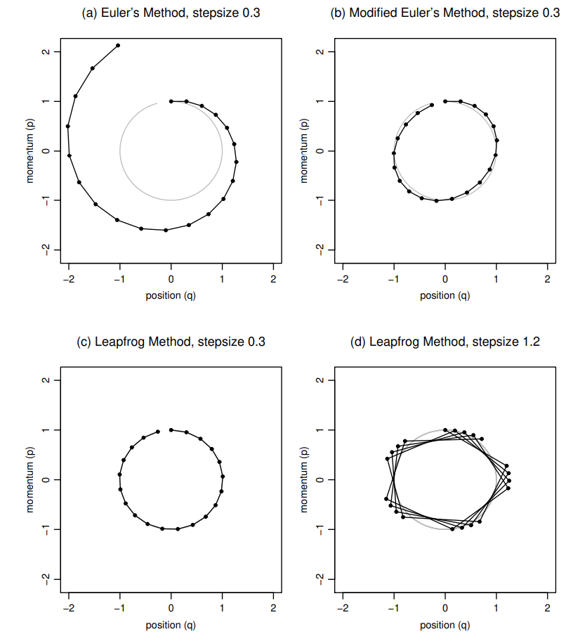

## Hamiltonian Monte Carlo

Using **Hamiltonian dynamics** to sample from a distribution requires translating the density to a **potential energy** function and introducing **momentum** variables. We can use the concept of a canonical distribution from statistical mechanics. Given an energy function $E(x)$ for a state $x$, the canonical distribution over states has density $P(x)=(1/Z)\mathrm{exp}(-E(x)/T)$, where $T$ is temperature and $Z$ is a normalizing constant. Using the Hamiltonian $H(\boldsymbol{q},\boldsymbol{p})=U(\boldsymbol{q})+K(\boldsymbol{p})$ as an energy function, we get

$$P(\boldsymbol{q},\boldsymbol{p}) = \frac{1}{Z}\mathrm{exp}(-U(\boldsymbol{q})/T)\mathrm{exp}(-K(\boldsymbol{p})/T).$$

We can see that $\boldsymbol{q}$ and $\boldsymbol{p}$ are independent, and both have canonical distributions. The former will be used to represent our variables of interest, and the latter for momentum.

## The Two Steps of HMC

Each **iteration** has **two steps**:

1. In the **first step**, new values for the **momentum variables** are drawn from their Gaussian distribution.
2. In the **second step**, a **Metropolis** update is performed using Hamiltonian dynamics as explained before. We get a proposed new state $(\boldsymbol{q}^*,\boldsymbol{p}^*)$. This state is accepted as the next state of the Markov chain with probability $\mathrm{min}\Big(1,\quad \mathrm{exp}(-H(\boldsymbol{q}^*,\boldsymbol{p}^*)+H(\boldsymbol{q},\boldsymbol{p}))\Big)\quad =\quad \mathrm{min}\Big(1,\quad \mathrm{exp} \big(-U(\boldsymbol{q}^*)+U(\boldsymbol{q})-K(\boldsymbol{p}^*)+K(\boldsymbol{p})\big)\Big).$ If the proposed state is not accepted, the next state is set equal to the current state.

## Benefits of HMC

We can use HMC to sample only from **continuous** distributions on $\mathbb{R}^d$ for which the **density** function can be evaluated and the **partial derivatives of its log** can be computed.

It allows us to **sample more efficiently** from such distributions **than simpler methods** such as random-walk Metropolis.

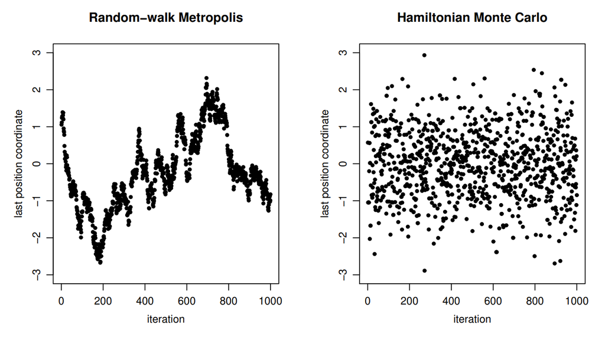

## Tuning HMC

However, in order to actually **attain the benefits** of HMC, we have to **properly tune** the **step size** $\varepsilon$ and the **trajectory length** $L$, i.e., the number of leapfrog steps. Tuning an **HMC algorithm** is also more difficult than tuning a **simple Metropolis** method.

- If the **step size** $\varepsilon$ is **too large**, acceptance rates will be low.
- If the **step size** $\varepsilon$ is **too small**, we will waste computation time.
- If the **trajectory length** $L$ is **too large**, trajectories may be long and still end up back at the starting point.
- If the **trajectory length** $L$ is **too small**, it may not reach far enough into unconstrained directions. In connection with a **small** **step size** $\varepsilon$, it may lead to slow exploration by a random walk.

## Illustration

[interactive chart not shown]

Intro and Recap

Hamiltonian Monte Carlo

# The No-U-Turn-Sampler (NUTS)

Our Implementation

Appendix

## Why NUTS?

We use **MCMC methods** usually to sample from **complicated distributions**.

- **Random-walk Metropolis** may take extremely long to converge to a target distribution.
- **Hamiltonian Monte Carlo** suppresses this random walk behavior.
  - This yields a much lower computational cost. The cost of a sample from a $d$-dimensional target distribution is $O(d^{5/4})$ for HMC, but $O(d^2)$ for random-walk Metropolis.
  - However, HMC requires the researcher to specify $\varepsilon$ and $L$.
  - Especially setting $L$ is costly itself, since it frequently requires multiple costly training runs.
- The **No-U-Turn-Sampler** (**NUTS**) eliminates the need to choose $L$, and an extension of it even allows for automatically tuning $\varepsilon$.

## Setting L

## Eliminating the Need to Set L

## NUTS

## Adaptively Tuning ε

## Dual-Averaging NUTS

## Illustration

[interactive chart not shown]

Intro and Recap

Hamiltonian Monte Carlo

The No-U-Turn-Sampler (NUTS)

# Our Implementation

Appendix

## Three peak density

[figure not shown]

## Three peak density

[figure not shown]

## Three peak density

[figure not shown]

## References

*This list is **scrollable**.*

Feng, C. (2017). *The markov-chain monte carlo interactive gallery* (Version c4723db). https://github.com/chi-feng/mcmc-demo.

Hoffman, M. D., Gelman, A., et al. (2014). The no-u-turn sampler: Adaptively setting path lengths in hamiltonian monte carlo. *J. Mach. Learn. Res.*, *15*(1), 1593–1623.

Hamiltonian Monte Carlo

The No-U-Turn-Sampler (NUTS)

Our Implementation